Laboratorio 5 - Periodismo de Datos Juvenal Campos 3/23/2020

# Laboratorio 5. Periodismo de Datos.

Vamos a seguir explorando las tablas de Contingencia para cruzar dos o mas variables entre si, asi como seguir practicando el uso de las bases de datos etiquetadas.

- El día de hoy vamos a revisar:
1. **Tareas:** Ver para que sirve cada uno de los paquetes que utilizamos.
2. **Ejemplo:** Utilizaremos una base de datos de admisiones a *cierta* universidad para ver si hay una discriminación por género en los procesos de admisión.

### Breve Comercial

Este ejemplo viene de la clase 5 del curso de la Escuela de Métodos de **Modelos estadísticos** de Javier Márquez [@JMarquezP](https://twitter.com/JMarquezP). Si estan interesados en el programa, la liga es la siguiente:

> https://www.lnpp.mx/evento/modelos-estadisticos/

Igualmente, para entender mejor el contexto de este problema, se recomienda leer el siguiente artículo de [Medium](https://medium.com/@dexter.shawn/how-uc-berkeley-almost-got-sued-because-of-lying-data-aaa5d641f571).

# Librerías a utilizar.

Utilizaremos las siguientes librerías:

- `sjlabelled`, para poner etiquetas a nuestras tibbles y data.frames.
- `sjmisc`, para poder realizar cruces de variables en bases de datos.
- `tidyverse`, para manipular bases de datos y usar la pipa `%>%`.

```r
# Cargamos las liberias:
library(sjlabelled)
library(sjmisc)
library(tidyverse)
```

Leemos la base de datos proveniente de la siguiente dirección web: https://raw.githubusercontent.com/JuveCampos/presentaciones/master/PdD2020/Admisiones.csv

```r
Ad <- read_csv("https://raw.githubusercontent.com/JuveCampos/presentaciones/master/PdD2020/Admisiones.csv")

head(Ad)
```

```
## # A tibble: 6 x 3
##   Admitido  Sexo Departamento
##      <dbl> <dbl> <chr>
## 1        1     1 A
## 2        1     1 A
## 3        1     1 A
## 4        1     1 A
## 5        1     1 A
## 6        1     1 A
```

Esta base de datos contiene información de solicitudes de admision estudiantiles a diversos programas de licenciatura de una *muy reconocida universidad de los Estados Unidos*.

Contiene 3 columnas, las cuales son:

- `Admitido`, la cual nos dice si un estudiante fué admitido o fué rechazado del programa de la universidad al que solicitó entrar.
- `Sexo`, el sexo del solicitante.
- `Departamento`, el departamento académico de la Universidad al cual solicitó el ingreso.

# Etiquetando variables.

A partir de esta base de datos, vamos a generar variables etiquetadas.

*Les pegamos el post-it encima.*

```r
# 1. Generamos las etiquetas de las columnas.
Ad$Admitido <- set_label(Ad$Admitido, "Condición de admisión a la Universidad")
Ad$Sexo <- set_label(Ad$Sexo, "Sexo o genero del aspirante")
Ad$Departamento <- set_label(Ad$Departamento, "Departamento académico")
```

# Asignación de claves a los valores de la variable.

Ahora generamos las claves de los datos de las variables.

**Claves:**

- En la columna *Admitido*:

> 1: admitido; 0: rechazado
- En la columna Sexo:

> 1: Hombre; 2:Mujer
- En la columna departamento, cada letra hace referencia a un Departamento Académico distinto, teniendo los siguientes departamentos: `A`, `B`, `C`, `D`, `E` y `F`.
- Recodemos, digo, recordemos como es el formato para hacer recodificación de una variable con el paquete `sjmisc`:

“ClaveVieja1 = ClaveNueva1 [TextoEtiqueta1];  
ClaveVieja2 = ClaveNueva2 [TextoEtiqueta2];  
…  
ClaveViejaN = ClaveNuevaN [TextoEtiquetaN]”

```r
# Recodificamos variables:
Ad <- Ad %>%
  mutate(Admitido = rec(Admitido, rec = "1=1 [Admitido]; 0=0 [Rechazado]"),
         Sexo = rec(Sexo, rec = "1=1 [Hombre]; 2=2 [Mujer]"))
```

# Análisis de los datos: generando flat_tables.

Ahora vamos a hacer los cruces de las variables. Recordemos del último laboratorio que los cruces los podemos hacer mediante las *tablas de contingencia*, las cuales *son tablas que se emplean para registrar y analizar la asociación entre dos o más variables, habitualmente de naturaleza cualitativa (nominales u ordinales)*.

- En este caso… **¿Qué nos interesa analizar?**

Dado que sospechamos que en esta escuela hay una discriminación por género en el proceso de admisión, vamos a analizar **primero** las proporciones de alumnos rechazados y aceptados dentro del proceso de admisión.

```r
# Generamos una flat table por renglones
flat_table(Ad, Admitido, Sexo, margin = "row")
```

```
##           Sexo Hombre Mujer
## Admitido
## Rechazado       53.88 46.12
## Admitido        68.26 31.74
```

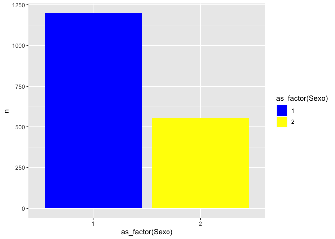

```r
# Grafica de admitidos:
Ad %>%
  filter(Admitido == 1) %>%
  group_by(Sexo) %>%
  count() %>%
  ggplot(aes(x = as_factor(Sexo), y = n, fill = as_factor(Sexo))) +
  geom_col() +
  scale_fill_manual(values = c("blue", "yellow"))
```

```r
# Generamos una flat table por columnas
flat_table(Ad, Admitido, Sexo, margin = "col")
```

```
##           Sexo Hombre Mujer
## Admitido
## Rechazado       55.48 69.65
## Admitido        44.52 30.35
```

*¿Que nos dice la tabla anterior?*

Que del total de mujeres que solicitaron admisión, fueron rechazadas casi el 70 % de ellas, mientras que de los hombres que solicitaron admisión, tan solo fueron rechazados el 55 %.

**¿A qué conclusión llegamos entonces al ver estas tablas? Comenten entre todos.**

# Desagregando los datos por Departamento.

Hay una variable que hace falta analizar: la admisión por departamento.

Para esto, vamos a desagregar los datos por departamento, para ver si hay departamentos que aportan más a la discriminación en las admisiones por género.

**¿Cómo se les ocurre que podamos afrontar esto analizando por departamento?. Comenten entre todos.**

```r
# 1. Cuantos departamentos hay?
get_labels(Ad$Departamento)
```

```
## [1] "A" "B" "C" "D" "E" "F"
```

```r
# Hay 6 departamentos.
```

```r
# Obtenemos una flat_table de 3 variables
flat_table(data = Ad, Admitido, Sexo, Departamento)
```

```
##                  Departamento   A   B   C   D   E   F
## Admitido  Sexo
## Rechazado Hombre              313 207 205 279 138 351
##           Mujer                19   8 391 244 299 317
## Admitido  Hombre              512 353 120 138  53  22
##           Mujer                89  17 202 131  94  24
```

```r
flat_table(data = Ad, Admitido, Sexo, Departamento, margin = "col")
```

```
##                  Departamento     A     B     C     D     E     F
## Admitido  Sexo
## Rechazado Hombre              33.55 35.38 22.33 35.23 23.63 49.16
##           Mujer                2.04  1.37 42.59 30.81 51.20 44.40
## Admitido  Hombre              54.88 60.34 13.07 17.42  9.08  3.08
##           Mujer                9.54  2.91 22.00 16.54 16.10  3.36
```

```r
# A

# Tabla
Ad %>%
  filter(Departamento == "A") %>%
  flat_table(Admitido, Sexo, margin = "row")
```

```
##           Sexo Hombre Mujer
## Admitido
## Rechazado       94.28  5.72
## Admitido        85.19 14.81
```

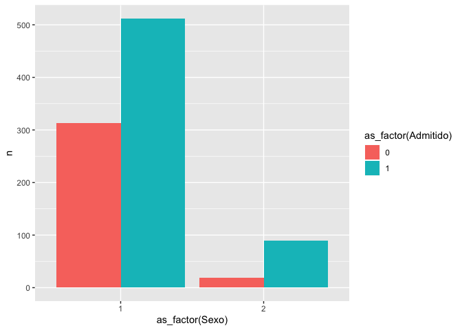

```r
# Grafica
Ad %>%
  group_by(Departamento, Sexo, Admitido) %>%
  count() %>%
  # Aqui contamos los admitidos y rechazados por Dpto y Sexo
  filter(Departamento == "A") %>%
  # Aqui nos quedamos solo con los del Dpto. A
  ggplot(aes(x = as_factor(Sexo),
             y = n,
             fill = as_factor(Admitido))) +
  # Aquí declaramos los elementos Estéticos (los canales de Segasi)
  geom_col(position = "dodge")
```

```r
  # Aquí declaramos los elementos Geométricos (las marcas de Segasi)
```

```r
# B
Ad %>%
  filter(Departamento == "B") %>%
  flat_table(Admitido, Sexo, margin = "row")
```

```
##           Sexo Hombre Mujer
## Admitido
## Rechazado       96.28  3.72
## Admitido        95.41  4.59
```

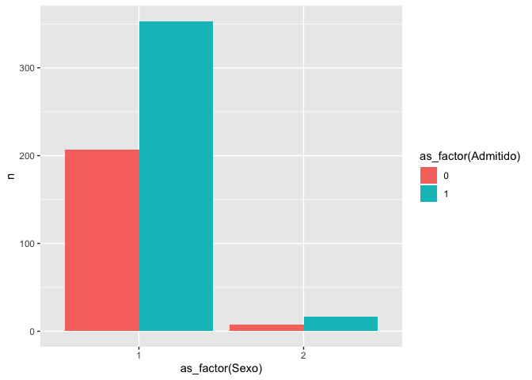

```r
# Grafica
Ad %>%
  group_by(Departamento, Sexo, Admitido) %>%
  count() %>%
  # Aqui contamos los admitidos y rechazados por Dpto y Sexo
  filter(Departamento == "B") %>%
  # Aqui nos quedamos solo con los del Dpto. A
  ggplot(aes(x = as_factor(Sexo),
             y = n,
             fill = as_factor(Admitido))) +
  # Aquí declaramos los elementos Estéticos (los canales de Segasi)
  geom_col(position = "dodge")
```

```r
  # Aquí declaramos los elementos Geométricos (las marcas de Segasi)

# C
Ad %>%
  filter(Departamento == "C") %>%
  flat_table(Admitido, Sexo, margin = "row")
```

```
##           Sexo Hombre Mujer
## Admitido
## Rechazado       34.40 65.60
## Admitido        37.27 62.73
```

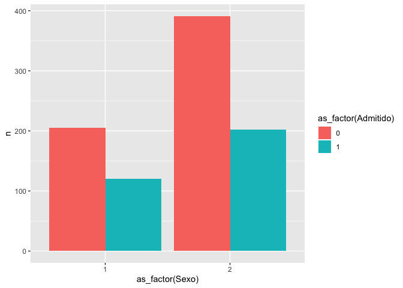

```r
# Grafica
Ad %>%
  group_by(Departamento, Sexo, Admitido) %>%
  count() %>%
  # Aqui contamos los admitidos y rechazados por Dpto y Sexo
  filter(Departamento == "C") %>%
  # Aqui nos quedamos solo con los del Dpto. A
  ggplot(aes(x = as_factor(Sexo),
             y = n,
             fill = as_factor(Admitido))) +
  # Aquí declaramos los elementos Estéticos (los canales de Segasi)
  geom_col(position = "dodge")
```

```r
  # Aquí declaramos los elementos Geométricos (las marcas de Segasi)

# D
Ad %>%
  filter(Departamento == "D") %>%
  flat_table(Admitido, Sexo, margin = "row")
```

```
##           Sexo Hombre Mujer
## Admitido
## Rechazado       53.35 46.65
## Admitido        51.30 48.70
```

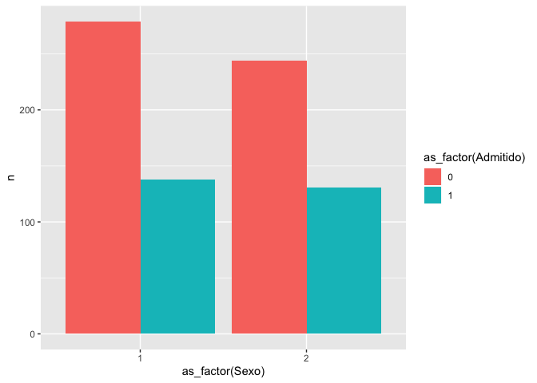

```r
# Grafica
Ad %>%
  group_by(Departamento, Sexo, Admitido) %>%
  count() %>%
  # Aqui contamos los admitidos y rechazados por Dpto y Sexo
  filter(Departamento == "D") %>%
  # Aqui nos quedamos solo con los del Dpto. A
  ggplot(aes(x = as_factor(Sexo),
             y = n,
             fill = as_factor(Admitido))) +
  # Aquí declaramos los elementos Estéticos (los canales de Segasi)
  geom_col(position = "dodge")
```

```r
  # Aquí declaramos los elementos Geométricos (las marcas de Segasi)

# E
Ad %>%
  filter(Departamento == "E") %>%
  flat_table(Admitido, Sexo, margin = "row")
```

```
##           Sexo Hombre Mujer
## Admitido
## Rechazado       31.58 68.42
## Admitido        36.05 63.95
```

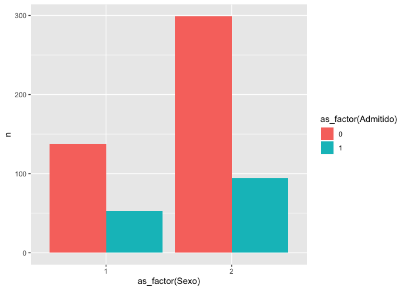

```r
# Grafica
Ad %>%
  group_by(Departamento, Sexo, Admitido) %>%
  count() %>%
  # Aqui contamos los admitidos y rechazados por Dpto y Sexo
  filter(Departamento == "E") %>%
  # Aqui nos quedamos solo con los del Dpto. A
  ggplot(aes(x = as_factor(Sexo),
             y = n,
             fill = as_factor(Admitido))) +
  # Aquí declaramos los elementos Estéticos (los canales de Segasi)
  geom_col(position = "dodge")
```

```r
  # Aquí declaramos los elementos Geométricos (las marcas de Segasi)
```

# Gráficas

Realizaremos ahora gráficas para hacer la comparativa final:

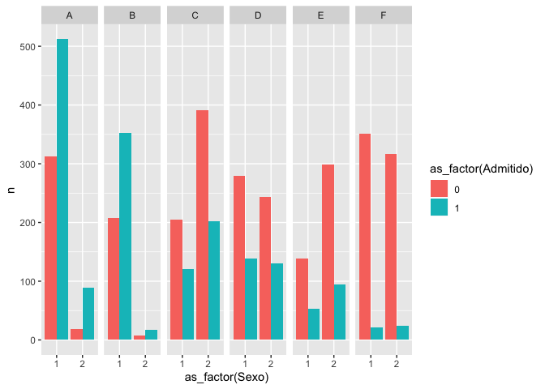

```r
# Librerias
library(ggplot2)

# Gr'aficas de admitidos
Ad %>%
  group_by(Departamento, Sexo, Admitido) %>%
  count() %>%
  ggplot(aes(x = as_factor(Sexo), y = n, fill = as_factor(Admitido))) +
  geom_col(position = "dodge") +
  facet_grid(. ~ Departamento)
```